# Data Mining - H4

Qin Xia, Li Wenhan, Yufeng Hu

2023-04-15

```
## Importance of components:
##                           PC1    PC2    PC3     PC4     PC5     PC6     PC7
## Standard deviation     1.7407 1.5792 1.2475 0.98517 0.84845 0.77930 0.72330
## Proportion of Variance 0.2754 0.2267 0.1415 0.08823 0.06544 0.05521 0.04756
## Cumulative Proportion  0.2754 0.5021 0.6436 0.73187 0.79732 0.85253 0.90009
##                            PC8     PC9   PC10    PC11
## Standard deviation     0.70817 0.58054 0.4772 0.18119
## Proportion of Variance 0.04559 0.03064 0.0207 0.00298
## Cumulative Proportion  0.94568 0.97632 0.9970 1.00000
```

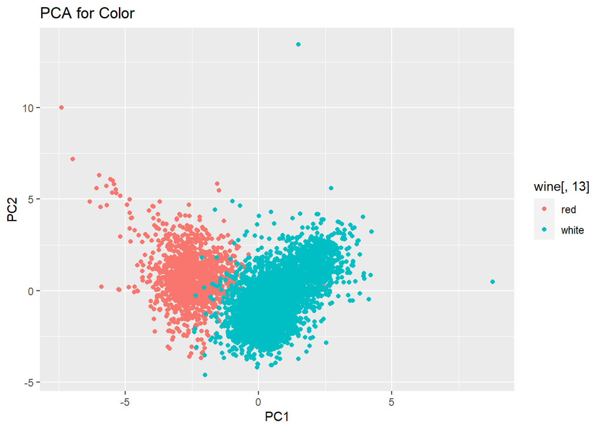

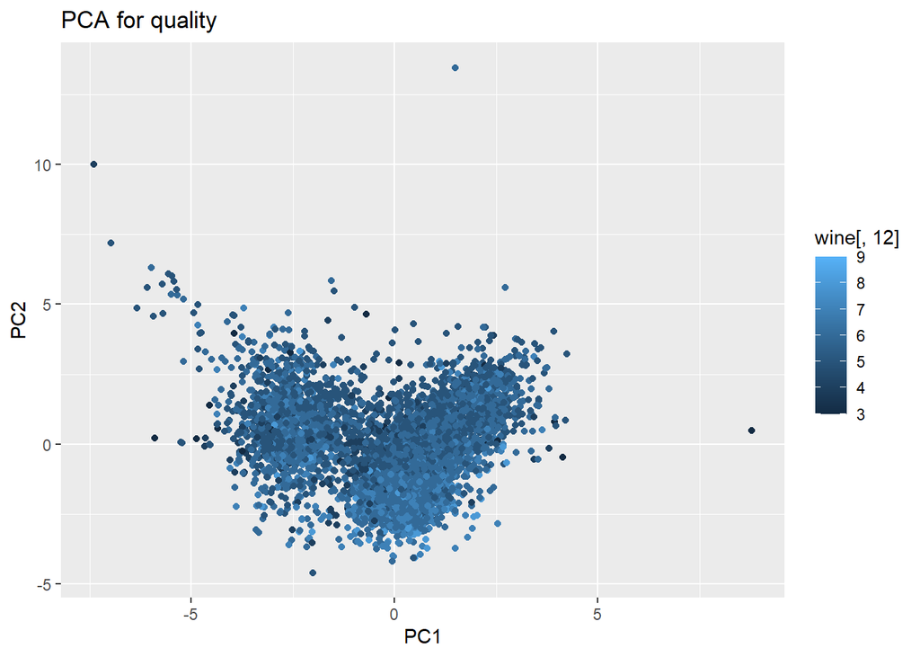

Based on the PCA plots, we can see that the red and white wines are mostly separated along the first principal component, indicating that this component captures much of the variation in wine type. Additionally, we can see some separation between higher and lower quality wines along the second principal component, indicating that this component captures some of the variation in wine quality, although the results are not as apparent.

```
##   cluster        x
## 1       1 5.888294
## 2       2 5.681818
```

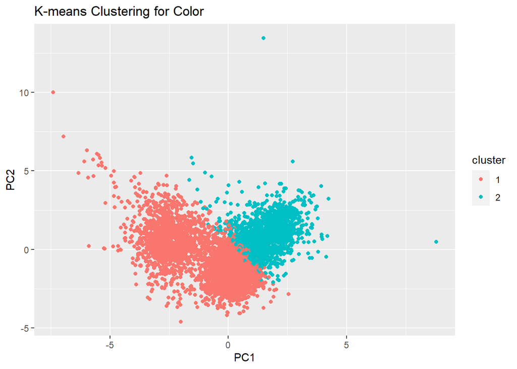

```
## [1] 5 6 7 4 8 3 9
```

[output not shown]

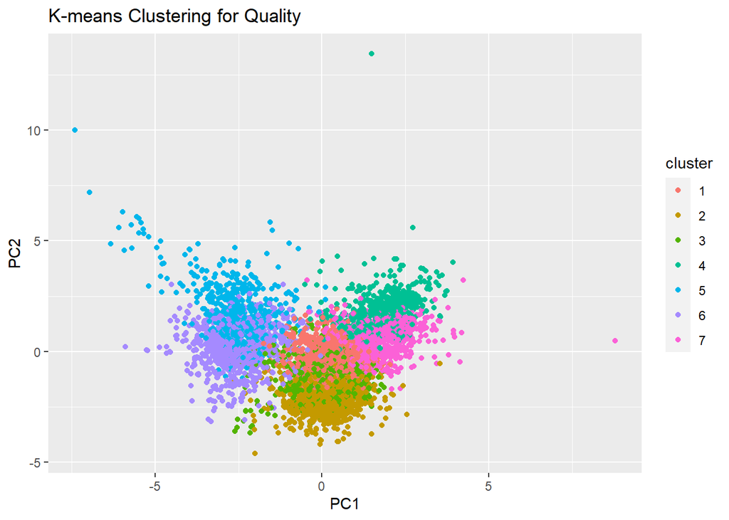